# Objetivo 4: Número de vuelos y retrasos en fechas significativas en comparación a sus vísperas y otros días

```r
media_retraso_por_dia2022 <- vuelos2022_repe %>%
  group_by(WEEKDAY_NAME = get_weekday_name(DAY_OF_WEEK)) %>%
  summarise(media_retraso = mean(salida_retraso))
media_retraso_por_dia2022$WEEKDAY_NAME <- factor(media_retraso_por_dia2022$WEEKDAY_NAME, levels = c("Lunes", "Martes", "Miércoles", "Jueves", "Viernes", "Sábado", "Domingo"))
print(media_retraso_por_dia2022)
```

```
## # A tibble: 7 × 2
##   WEEKDAY_NAME media_retraso
##   <fct>                <dbl>
## 1 Domingo               17.0
## 2 Jueves                15.8
## 3 Lunes                 15.6
## 4 Martes                12.5
## 5 Miércoles             12.7
## 6 Sábado                16.7
## 7 Viernes               17.8
```

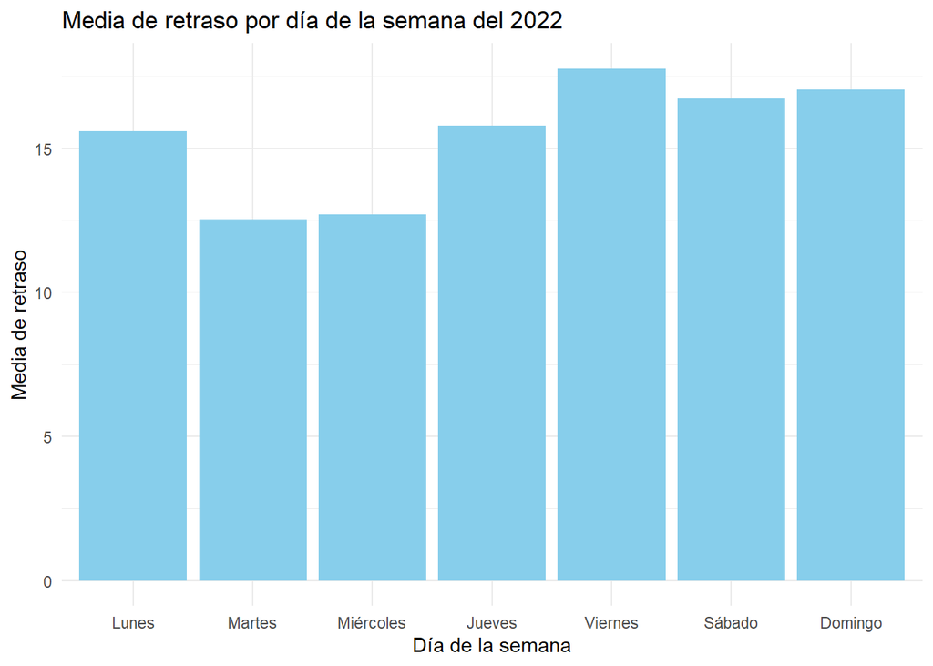

```r
ggplot(media_retraso_por_dia2022, aes(x = WEEKDAY_NAME, y = media_retraso)) +
  geom_bar(stat = "identity", fill = "skyblue") +
  labs(title = "Media de retraso por día de la semana del 2022",
       x = "Día de la semana",
       y = "Media de retraso") +
  theme_minimal()
```

```r
vuelos2021_repe <- vuelos2021
vuelos2021_repe$MONTH <- factor(vuelos2021_repe$MONTH, levels = 1:12, labels = month.abb)
media_retraso_por_mes2021 <- vuelos2021_repe %>%
  group_by(MONTH) %>%
  summarise(media_retraso = mean(salida_retraso))
print(media_retraso_por_mes2021)
```

```
## # A tibble: 12 × 2
##    MONTH media_retraso
##    <fct>         <dbl>
##  1 Jan            6.86
##  2 Feb            9.60
##  3 Mar            7.16
##  4 Apr            7.79
##  5 May            9.99
##  6 Jun           18.4
##  7 Jul           19.4
##  8 Aug           17.4
##  9 Sep           10.4
## 10 Oct           13.3
## 11 Nov           10.7
## 12 Dec           16.0
```

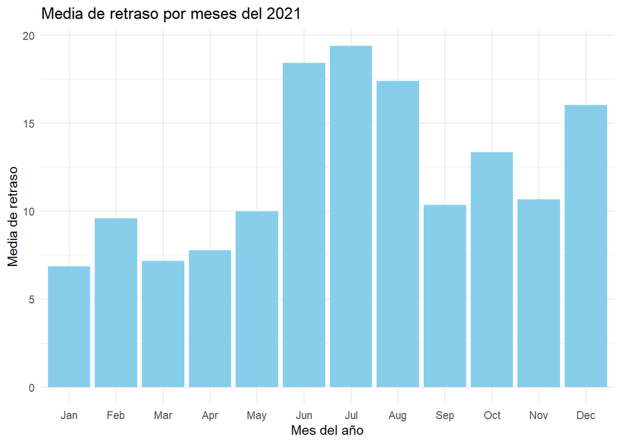

```r
ggplot(media_retraso_por_mes2021, aes(x = MONTH, y = media_retraso)) +
  geom_bar(stat = "identity", fill = "skyblue") +
  labs(title = "Media de retraso por meses del 2021",
       x = "Mes del año",
       y = "Media de retraso") +
  theme_minimal()
```

```r
media_retraso_por_dia2021 <- vuelos_repe %>%
  group_by(WEEKDAY_NAME = get_weekday_name(DAY_OF_WEEK)) %>%
  summarise(media_retraso = mean(salida_retraso))
media_retraso_por_dia2021$WEEKDAY_NAME <- factor(media_retraso_por_dia2021$WEEKDAY_NAME, levels = c("Lunes", "Martes", "Miércoles", "Jueves", "Viernes", "Sábado", "Domingo"))
print(media_retraso_por_dia2021)
```

```
## # A tibble: 7 × 2
##   WEEKDAY_NAME media_retraso
##   <fct>                <dbl>
## 1 Domingo               17.3
## 2 Jueves                15.2
## 3 Lunes                 15.4
## 4 Martes                12.9
## 5 Miércoles             14.3
## 6 Sábado                15.6
## 7 Viernes               16.4
```

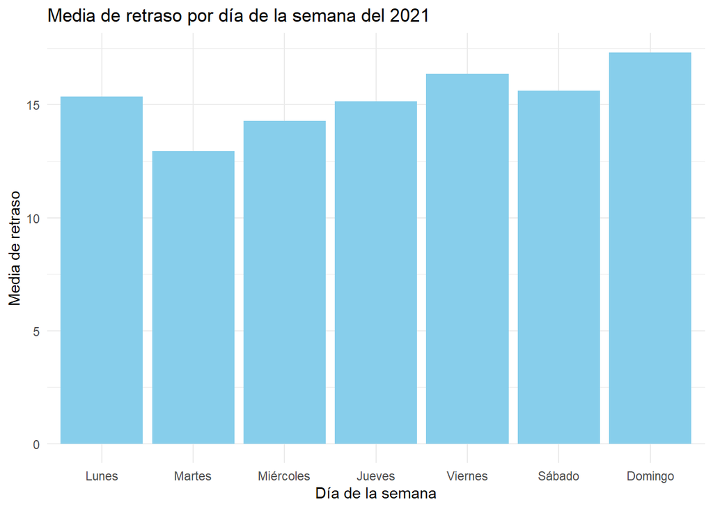

```r
ggplot(media_retraso_por_dia2021, aes(x = WEEKDAY_NAME, y = media_retraso)) +
  geom_bar(stat = "identity", fill = "skyblue") +
  labs(title = "Media de retraso por día de la semana del 2021",
       x = "Día de la semana",
       y = "Media de retraso") +
  theme_minimal()
```

Una vez tenemos los gráficos y tablas que nos muestran los retrasos de los vuelos durante el 2023, 2022 y 2021 tanto por meses como por días de la semana comenzamos a mirar en específico los días de nuestros festivos.

## 4.2 Año Nuevo

### 4.2.1 2023

Vamos a comenzar con los festivos de Año Nuevo(1 Enero) y Navidad(25 Diciembre).

```r
vuelos_1E <- vuelos[vuelos$MONTH == 1 & vuelos$DAY_OF_MONTH == 1, ]
media_retraso_1E <- vuelos_1E %>%
  group_by(DAY_OF_MONTH) %>%
  summarise(media_retraso = mean(salida_retraso))
print(media_retraso_1E)
```

```
## # A tibble: 1 × 2
##   DAY_OF_MONTH media_retraso
##          <int>         <dbl>
## 1            1          21.4
```

```r
vuelos_2E <- vuelos[vuelos$MONTH == 1 & vuelos$DAY_OF_MONTH == 2, ]
media_retraso_2E <- vuelos_2E %>%
  group_by(DAY_OF_MONTH) %>%
  summarise(media_retraso = mean(salida_retraso))
print(media_retraso_2E)
```

```
## # A tibble: 1 × 2
##   DAY_OF_MONTH media_retraso
##          <int>         <dbl>
## 1            2          35.0
```

```r
vuelos_3E <- vuelos[vuelos$MONTH == 1 & vuelos$DAY_OF_MONTH == 3, ]
media_retraso_3E <- vuelos_3E %>%
  group_by(DAY_OF_MONTH) %>%
  summarise(media_retraso = mean(salida_retraso))
print(media_retraso_3E)
```

```
## # A tibble: 1 × 2
##   DAY_OF_MONTH media_retraso
##          <int>         <dbl>
## 1            3          30.7
```

```r
vuelos_31D <- vuelos2022[vuelos2022$MONTH == 12 & vuelos2022$DAY_OF_MONTH == 31, ]
media_retraso_31D <- vuelos_31D %>%
  group_by(DAY_OF_MONTH) %>%
  summarise(media_retraso = mean(salida_retraso))
print(media_retraso_31D)
```

```
## # A tibble: 1 × 2
##   DAY_OF_MONTH media_retraso
##          <int>         <dbl>
## 1           31          20.8
```

```r
vuelos_30D <- vuelos2022[vuelos2022$MONTH == 12 & vuelos2022$DAY_OF_MONTH == 30, ]
media_retraso_30D <- vuelos_30D %>%
  group_by(DAY_OF_MONTH) %>%
  summarise(media_retraso = mean(salida_retraso))
print(media_retraso_30D)
```

```
## # A tibble: 1 × 2
##   DAY_OF_MONTH media_retraso
##          <int>         <dbl>
## 1           30          17.0
```

```r
print(dias[vuelos[vuelos$DAY_OF_MONTH == 1 & vuelos$MONTH == 1, ]$DAY_OF_WEEK[1]])
```

```
## [1] "Domingo"
```

```r
vuelosE_repe <- vuelos[vuelos$MONTH==1,]

media_retrasoE <- vuelosE_repe %>%
  group_by(WEEKDAY_NAME = get_weekday_name(DAY_OF_WEEK)) %>%
  summarise(media_retraso = mean(salida_retraso))
media_retrasoE$WEEKDAY_NAME <- factor(media_retrasoE$WEEKDAY_NAME, levels = c("Lunes", "Martes", "Miércoles", "Jueves", "Viernes", "Sábado", "Domingo"))

media_retraso_domingoE <- media_retrasoE %>%
  filter(WEEKDAY_NAME == "Domingo")

media_retraso_lunesE <- media_retrasoE %>%
  filter(WEEKDAY_NAME == "Lunes")

media_retraso_martesE <- media_retrasoE %>%
  filter(WEEKDAY_NAME == "Martes")

media_retraso_sabadoE <- media_retrasoE %>%
  filter(WEEKDAY_NAME == "Sábado")

media_retraso_viernesE <- media_retrasoE %>%
  filter(WEEKDAY_NAME == "Viernes")

media_retraso_juevesE <- media_retrasoE %>%
  filter(WEEKDAY_NAME == "Jueves")

media_retraso_miercolesE <- media_retrasoE %>%
  filter(WEEKDAY_NAME == "Miércoles")

vuelosD_repe <- vuelos[vuelos$MONTH==12,]

media_retrasoD <- vuelosD_repe %>%
  group_by(WEEKDAY_NAME = get_weekday_name(DAY_OF_WEEK)) %>%
  summarise(media_retraso = mean(salida_retraso))
media_retrasoD$WEEKDAY_NAME <- factor(media_retrasoD$WEEKDAY_NAME, levels = c("Lunes", "Martes", "Miércoles", "Jueves", "Viernes", "Sábado", "Domingo"))

media_retraso_domingoD <- media_retrasoD %>%
  filter(WEEKDAY_NAME == "Domingo")

media_retraso_lunesD <- media_retrasoD %>%
  filter(WEEKDAY_NAME == "Lunes")

media_retraso_martesD <- media_retrasoD %>%
  filter(WEEKDAY_NAME == "Martes")

media_retraso_sabadoD <- media_retrasoD %>%
  filter(WEEKDAY_NAME == "Sábado")

media_retraso_viernesD <- media_retrasoD %>%
  filter(WEEKDAY_NAME == "Viernes")

media_retraso_juevesD <- media_retrasoD %>%
  filter(WEEKDAY_NAME == "Jueves")

media_retraso_miercolesD <- media_retrasoD %>%
  filter(WEEKDAY_NAME == "Miércoles")

vuelosE22_repe <- vuelos2022[vuelos2022$MONTH==1,]

media_retrasoE22 <- vuelosE22_repe %>%
  group_by(WEEKDAY_NAME = get_weekday_name(DAY_OF_WEEK)) %>%
  summarise(media_retraso = mean(salida_retraso))
media_retrasoE22$WEEKDAY_NAME <- factor(media_retrasoE22$WEEKDAY_NAME, levels = c("Lunes", "Martes", "Miércoles", "Jueves", "Viernes", "Sábado", "Domingo"))

media_retraso_domingoE22 <- media_retrasoE22 %>%
  filter(WEEKDAY_NAME == "Domingo")

media_retraso_lunesE22 <- media_retrasoE22 %>%
  filter(WEEKDAY_NAME == "Lunes")

media_retraso_martesE22 <- media_retrasoE22 %>%
  filter(WEEKDAY_NAME == "Martes")

media_retraso_sabadoE22 <- media_retrasoE22 %>%
  filter(WEEKDAY_NAME == "Sábado")

media_retraso_viernesE22 <- media_retrasoE22 %>%
  filter(WEEKDAY_NAME == "Viernes")

media_retraso_juevesE22 <- media_retrasoE22 %>%
  filter(WEEKDAY_NAME == "Jueves")

media_retraso_miercolesE22 <- media_retrasoE22 %>%
  filter(WEEKDAY_NAME == "Miércoles")

vuelosD22_repe <- vuelos2022[vuelos2022$MONTH==12,]

media_retrasoD22 <- vuelosD22_repe %>%
  group_by(WEEKDAY_NAME = get_weekday_name(DAY_OF_WEEK)) %>%
  summarise(media_retraso = mean(salida_retraso))
media_retrasoD22$WEEKDAY_NAME <- factor(media_retrasoD22$WEEKDAY_NAME, levels = c("Lunes", "Martes", "Miércoles", "Jueves", "Viernes", "Sábado", "Domingo"))

media_retraso_domingoD22 <- media_retrasoD22 %>%
  filter(WEEKDAY_NAME == "Domingo")

media_retraso_lunesD22 <- media_retrasoD22 %>%
  filter(WEEKDAY_NAME == "Lunes")

media_retraso_martesD22 <- media_retrasoD22 %>%
  filter(WEEKDAY_NAME == "Martes")

media_retraso_sabadoD22 <- media_retrasoD22 %>%
  filter(WEEKDAY_NAME == "Sábado")

media_retraso_viernesD22 <- media_retrasoD22 %>%
  filter(WEEKDAY_NAME == "Viernes")

media_retraso_juevesD22 <- media_retrasoD22 %>%
  filter(WEEKDAY_NAME == "Jueves")

media_retraso_miercolesD22 <- media_retrasoD22 %>%
  filter(WEEKDAY_NAME == "Miércoles")

vuelosD21_repe <- vuelos2021[vuelos2021$MONTH==12,]

media_retrasoD21 <- vuelosD21_repe %>%
  group_by(WEEKDAY_NAME = get_weekday_name(DAY_OF_WEEK)) %>%
  summarise(media_retraso = mean(salida_retraso))
media_retrasoD21$WEEKDAY_NAME <- factor(media_retrasoD21$WEEKDAY_NAME, levels = c("Lunes", "Martes", "Miércoles", "Jueves", "Viernes", "Sábado", "Domingo"))

media_retraso_domingoD21 <- media_retrasoD21 %>%
  filter(WEEKDAY_NAME == "Domingo")

media_retraso_lunesD21 <- media_retrasoD21 %>%
  filter(WEEKDAY_NAME == "Lunes")

media_retraso_martesD21 <- media_retrasoD21 %>%
  filter(WEEKDAY_NAME == "Martes")

media_retraso_sabadoD21 <- media_retrasoD21 %>%
  filter(WEEKDAY_NAME == "Sábado")

media_retraso_viernesD21 <- media_retrasoD21 %>%
  filter(WEEKDAY_NAME == "Viernes")

media_retraso_juevesD21 <- media_retrasoD21 %>%
  filter(WEEKDAY_NAME == "Jueves")

media_retraso_miercolesD21 <- media_retrasoD21 %>%
  filter(WEEKDAY_NAME == "Miércoles")

vuelosJ_repe <- vuelos[vuelos$MONTH==7,]

media_retrasoJ <- vuelosJ_repe %>%
  group_by(WEEKDAY_NAME = get_weekday_name(DAY_OF_WEEK)) %>%
  summarise(media_retraso = mean(salida_retraso))
media_retrasoJ$WEEKDAY_NAME <- factor(media_retrasoJ$WEEKDAY_NAME, levels = c("Lunes", "Martes", "Miércoles", "Jueves", "Viernes", "Sábado", "Domingo"))

media_retraso_domingoJ <- media_retrasoJ %>%
  filter(WEEKDAY_NAME == "Domingo")

media_retraso_lunesJ <- media_retrasoJ %>%
  filter(WEEKDAY_NAME == "Lunes")

media_retraso_martesJ <- media_retrasoJ %>%
  filter(WEEKDAY_NAME == "Martes")

media_retraso_sabadoJ <- media_retrasoJ %>%
  filter(WEEKDAY_NAME == "Sábado")

media_retraso_viernesJ <- media_retrasoJ %>%
  filter(WEEKDAY_NAME == "Viernes")

media_retraso_juevesJ <- media_retrasoJ %>%
  filter(WEEKDAY_NAME == "Jueves")

media_retraso_miercolesJ <- media_retrasoJ %>%
  filter(WEEKDAY_NAME == "Miércoles")

vuelosJ22_repe <- vuelos2022[vuelos2022$MONTH==7,]

media_retrasoJ22 <- vuelosJ22_repe %>%
  group_by(WEEKDAY_NAME = get_weekday_name(DAY_OF_WEEK)) %>%
  summarise(media_retraso = mean(salida_retraso))
media_retrasoJ22$WEEKDAY_NAME <- factor(media_retrasoJ22$WEEKDAY_NAME, levels = c("Lunes", "Martes", "Miércoles", "Jueves", "Viernes", "Sábado", "Domingo"))

media_retraso_domingoJ22 <- media_retrasoJ22 %>%
  filter(WEEKDAY_NAME == "Domingo")

media_retraso_lunesJ22 <- media_retrasoJ22 %>%
  filter(WEEKDAY_NAME == "Lunes")

media_retraso_martesJ22 <- media_retrasoJ22 %>%
  filter(WEEKDAY_NAME == "Martes")

media_retraso_sabadoJ22 <- media_retrasoJ22 %>%
  filter(WEEKDAY_NAME == "Sábado")

media_retraso_viernesJ22 <- media_retrasoJ22 %>%
  filter(WEEKDAY_NAME == "Viernes")

media_retraso_juevesJ22 <- media_retrasoJ22 %>%
  filter(WEEKDAY_NAME == "Jueves")

media_retraso_miercolesJ22 <- media_retrasoJ22 %>%
  filter(WEEKDAY_NAME == "Miércoles")

vuelosJ21_repe <- vuelos2021[vuelos2021$MONTH==7,]

media_retrasoJ21 <- vuelosJ21_repe %>%
  group_by(WEEKDAY_NAME = get_weekday_name(DAY_OF_WEEK)) %>%
  summarise(media_retraso = mean(salida_retraso))
media_retrasoJ21$WEEKDAY_NAME <- factor(media_retrasoJ21$WEEKDAY_NAME, levels = c("Lunes", "Martes", "Miércoles", "Jueves", "Viernes", "Sábado", "Domingo"))

media_retraso_domingoJ21 <- media_retrasoJ21 %>%
  filter(WEEKDAY_NAME == "Domingo")

media_retraso_lunesJ21 <- media_retrasoJ21 %>%
  filter(WEEKDAY_NAME == "Lunes")

media_retraso_martesJ21 <- media_retrasoJ21 %>%
  filter(WEEKDAY_NAME == "Martes")

media_retraso_sabadoJ21 <- media_retrasoJ21 %>%
  filter(WEEKDAY_NAME == "Sábado")

media_retraso_viernesJ21 <- media_retrasoJ21 %>%
  filter(WEEKDAY_NAME == "Viernes")

media_retraso_juevesJ21 <- media_retrasoJ21 %>%
  filter(WEEKDAY_NAME == "Jueves")

media_retraso_miercolesJ21 <- media_retrasoJ21 %>%
  filter(WEEKDAY_NAME == "Miércoles")

vuelosN_repe <- vuelos[vuelos$MONTH==11,]

media_retrasoN <- vuelosN_repe %>%
  group_by(WEEKDAY_NAME = get_weekday_name(DAY_OF_WEEK)) %>%
  summarise(media_retraso = mean(salida_retraso))
media_retrasoN$WEEKDAY_NAME <- factor(media_retrasoN$WEEKDAY_NAME, levels = c("Lunes", "Martes", "Miércoles", "Jueves", "Viernes", "Sábado", "Domingo"))

media_retraso_domingoN <- media_retrasoN %>%
  filter(WEEKDAY_NAME == "Domingo")

media_retraso_lunesN <- media_retrasoN %>%
  filter(WEEKDAY_NAME == "Lunes")

media_retraso_martesN <- media_retrasoN %>%
  filter(WEEKDAY_NAME == "Martes")

media_retraso_sabadoN <- media_retrasoN %>%
  filter(WEEKDAY_NAME == "Sábado")

media_retraso_viernesN <- media_retrasoN %>%
  filter(WEEKDAY_NAME == "Viernes")

media_retraso_juevesN <- media_retrasoN %>%
  filter(WEEKDAY_NAME == "Jueves")

media_retraso_miercolesN <- media_retrasoN %>%
  filter(WEEKDAY_NAME == "Miércoles")

vuelosN22_repe <- vuelos2022[vuelos2022$MONTH==11,]

media_retrasoN22 <- vuelosN22_repe %>%
  group_by(WEEKDAY_NAME = get_weekday_name(DAY_OF_WEEK)) %>%
  summarise(media_retraso = mean(salida_retraso))
media_retrasoN22$WEEKDAY_NAME <- factor(media_retrasoN22$WEEKDAY_NAME, levels = c("Lunes", "Martes", "Miércoles", "Jueves", "Viernes", "Sábado", "Domingo"))

media_retraso_domingoN22 <- media_retrasoN22 %>%
  filter(WEEKDAY_NAME == "Domingo")

media_retraso_lunesN22 <- media_retrasoN22 %>%
  filter(WEEKDAY_NAME == "Lunes")

media_retraso_martesN22 <- media_retrasoN22 %>%
  filter(WEEKDAY_NAME == "Martes")

media_retraso_sabadoN22 <- media_retrasoN22 %>%
  filter(WEEKDAY_NAME == "Sábado")

media_retraso_viernesN22 <- media_retrasoN22 %>%
  filter(WEEKDAY_NAME == "Viernes")

media_retraso_juevesN22 <- media_retrasoN22 %>%
  filter(WEEKDAY_NAME == "Jueves")

media_retraso_miercolesN22 <- media_retrasoN22 %>%
  filter(WEEKDAY_NAME == "Miércoles")

vuelosN21_repe <- vuelos2021[vuelos2021$MONTH==11,]

media_retrasoN21 <- vuelosN21_repe %>%
  group_by(WEEKDAY_NAME = get_weekday_name(DAY_OF_WEEK)) %>%
  summarise(media_retraso = mean(salida_retraso))
media_retrasoN21$WEEKDAY_NAME <- factor(media_retrasoN21$WEEKDAY_NAME, levels = c("Lunes", "Martes", "Miércoles", "Jueves", "Viernes", "Sábado", "Domingo"))

media_retraso_domingoN21 <- media_retrasoN21 %>%
  filter(WEEKDAY_NAME == "Domingo")

media_retraso_lunesN21 <- media_retrasoN21 %>%
  filter(WEEKDAY_NAME == "Lunes")

media_retraso_martesN21 <- media_retrasoN21 %>%
  filter(WEEKDAY_NAME == "Martes")

media_retraso_sabadoN21 <- media_retrasoN21 %>%
  filter(WEEKDAY_NAME == "Sábado")

media_retraso_viernesN21 <- media_retrasoN21 %>%
  filter(WEEKDAY_NAME == "Viernes")

media_retraso_juevesN21 <- media_retrasoN21 %>%
  filter(WEEKDAY_NAME == "Jueves")

media_retraso_miercolesN21 <- media_retrasoN21 %>%
  filter(WEEKDAY_NAME == "Miércoles")
```

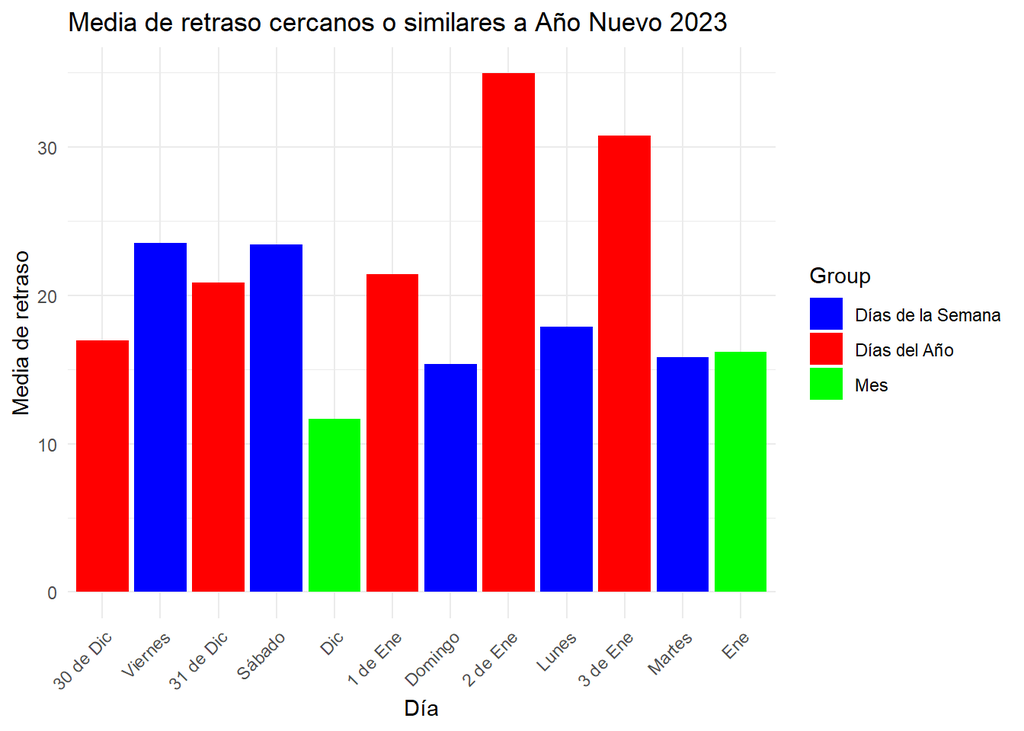

```r
media_retraso_31D <- media_retraso_31D %>%
  mutate(WEEKDAY_NAME = "31 de Dic")

media_retraso_30D <- media_retraso_30D %>%
  mutate(WEEKDAY_NAME = "30 de Dic")

media_retraso_1E <- media_retraso_1E %>%
  mutate(WEEKDAY_NAME = "1 de Ene")

media_retraso_2E <- media_retraso_2E %>%
  mutate(WEEKDAY_NAME = "2 de Ene")

media_retraso_3E <- media_retraso_3E %>%
  mutate(WEEKDAY_NAME = "3 de Ene")

media_retraso_enero <- media_retraso_por_mes2023 %>%
  filter(MONTH == "Jan") %>%
  mutate(WEEKDAY_NAME = "Ene")

media_retraso_diciembre <- media_retraso_por_mes2023 %>%
  filter(MONTH == "Dec") %>%
  mutate(WEEKDAY_NAME = "Dic")

combined_data <- bind_rows(media_retraso_domingoE, media_retraso_1E, media_retraso_enero, media_retraso_2E, media_retraso_3E, media_retraso_31D, media_retraso_30D, media_retraso_lunesE, media_retraso_martesE, media_retraso_viernesD22, media_retraso_sabadoD22, media_retraso_diciembre)

combined_data <- combined_data %>%
  mutate(WEEKDAY_NAME = factor(WEEKDAY_NAME, levels = c("30 de Dic", "Viernes", "31 de Dic", "Sábado",  "Dic", "1 de Ene", "Domingo", "2 de Ene", "Lunes", "3 de Ene", "Martes", "Ene")),
         Group = case_when(
           WEEKDAY_NAME %in% c("30 de Dic", "31 de Dic", "1 de Ene", "2 de Ene", "3 de Ene") ~ "Días del Año",
           WEEKDAY_NAME %in% c("Dic", "Ene") ~ "Mes",
           TRUE ~ "Días de la Semana"
         ))

ggplot(combined_data, aes(x = WEEKDAY_NAME, y = media_retraso, fill = Group)) +
  geom_bar(stat = "identity") +
  scale_fill_manual(values = c("Días del Año" = "red", "Mes" = "green", "Días de la Semana" = "blue")) +
  labs(title = "Media de retraso cercanos o similares a Año Nuevo 2023",
       x = "Día",
       y = "Media de retraso") +
  theme_minimal()+
  theme(axis.text.x = element_text(angle = 45, hjust = 1))
```

Observamos que la media de retrasos el día del festivo y los días cercanos son más altas que la media del mes al que pertenecen, pero vemos que en los previos no supera la media de ese día de la semana, lo que podría deberse a que en navidades el retraso medío aumenta a finales de diciembre, causando que la media de ciertos días de la semana sea más elevada que lo normal. Vamos a comprobar ahora en otros festivos, para observar si realmente la tendencia de los días previos y posteriores a los festivos es el aumento del retraso.

### 4.2.2 2022

```r
vuelos_1E_2022 <- vuelos2022[vuelos2022$MONTH == 1 & vuelos2022$DAY_OF_MONTH == 1, ]
media_retraso_1E_2022 <- vuelos_1E_2022 %>%
  group_by(DAY_OF_MONTH) %>%
  summarise(media_retraso = mean(salida_retraso,))
print(media_retraso_1E_2022)
```

```
## # A tibble: 1 × 2
##   DAY_OF_MONTH media_retraso
##          <int>         <dbl>
## 1            1          30.6
```

```r
vuelos_2E_2022 <- vuelos2022[vuelos2022$MONTH == 1 & vuelos2022$DAY_OF_MONTH == 2, ]
media_retraso_2E_2022 <- vuelos_2E_2022 %>%
  group_by(DAY_OF_MONTH) %>%
  summarise(media_retraso = mean(salida_retraso))
print(media_retraso_2E_2022)
```

```
## # A tibble: 1 × 2
##   DAY_OF_MONTH media_retraso
##          <int>         <dbl>
## 1            2          38.8
```

```r
vuelos_3E_2022 <- vuelos2022[vuelos2022$MONTH == 1 & vuelos2022$DAY_OF_MONTH == 3, ]
media_retraso_3E_2022 <- vuelos_3E_2022 %>%
  group_by(DAY_OF_MONTH) %>%
  summarise(media_retraso = mean(salida_retraso))
print(media_retraso_3E_2022)
```

```
## # A tibble: 1 × 2
##   DAY_OF_MONTH media_retraso
##          <int>         <dbl>
## 1            3          34.6
```

```r
vuelos_31D_2022 <- vuelos2022[vuelos2022$MONTH == 12 & vuelos2022$DAY_OF_MONTH == 31, ]
media_retraso_31D_2022 <- vuelos_31D_2022 %>%
  group_by(DAY_OF_MONTH) %>%
  summarise(media_retraso = mean(salida_retraso))
print(media_retraso_31D_2022)
```

```
## # A tibble: 1 × 2
##   DAY_OF_MONTH media_retraso
##          <int>         <dbl>
## 1           31          20.8
```

```r
vuelos_30D_2022 <- vuelos2022[vuelos2022$MONTH == 12 & vuelos2022$DAY_OF_MONTH == 30, ]
media_retraso_30D_2022 <- vuelos_30D_2022 %>%
  group_by(DAY_OF_MONTH) %>%
  summarise(media_retraso = mean(salida_retraso))
print(media_retraso_30D_2022)
```

```
## # A tibble: 1 × 2
##   DAY_OF_MONTH media_retraso
##          <int>         <dbl>
## 1           30          17.0
```

```r
print(dias[vuelos2022[vuelos2022$DAY_OF_MONTH == 1 & vuelos2022$MONTH == 1, ]$DAY_OF_WEEK[1]])
```

```
## [1] "Sabado"
```

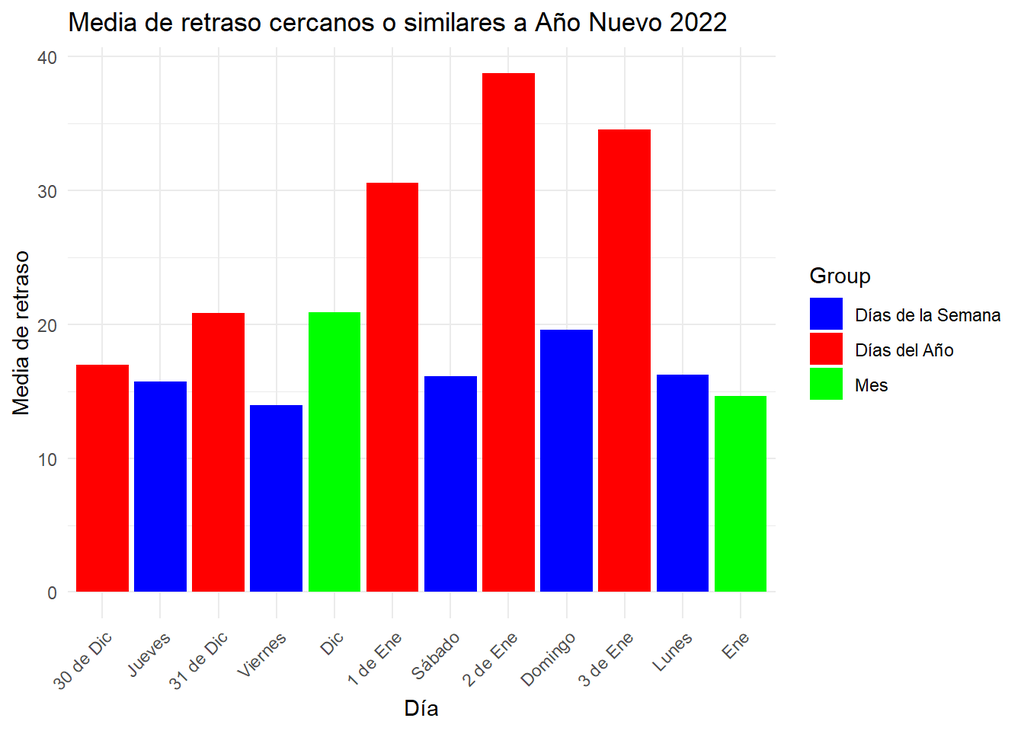

```r
media_retraso_1E_2022 <- media_retraso_1E_2022 %>%
  mutate(WEEKDAY_NAME = "1 de Ene")

media_retraso_2E_2022 <- media_retraso_2E_2022 %>%
  mutate(WEEKDAY_NAME = "2 de Ene")

media_retraso_3E_2022 <- media_retraso_3E_2022 %>%
  mutate(WEEKDAY_NAME = "3 de Ene")

media_retraso_31D_2022 <- media_retraso_31D_2022 %>%
  mutate(WEEKDAY_NAME = "31 de Dic")

media_retraso_30D_2022 <- media_retraso_30D_2022 %>%
  mutate(WEEKDAY_NAME = "30 de Dic")

media_retraso_enero_2022 <- media_retraso_por_mes2022 %>%
  filter(MONTH == "Jan") %>%
  mutate(WEEKDAY_NAME = "Ene")

media_retraso_diciembre_2022 <- media_retraso_por_mes2022 %>%
  filter(MONTH == "Dec") %>%
  mutate(WEEKDAY_NAME = "Dic")

combined_data <- bind_rows(media_retraso_domingoE22, media_retraso_1E_2022, media_retraso_enero_2022, media_retraso_diciembre_2022, media_retraso_2E_2022, media_retraso_3E_2022, media_retraso_31D_2022, media_retraso_30D_2022, media_retraso_lunesE22, media_retraso_juevesD21, media_retraso_viernesD21, media_retraso_sabadoE22)

combined_data <- combined_data %>%
  mutate(WEEKDAY_NAME = factor(WEEKDAY_NAME, levels = c("30 de Dic", "Jueves", "31 de Dic", "Viernes", "Dic", "1 de Ene", "Sábado", "2 de Ene", "Domingo", "3 de Ene", "Lunes", "Ene")),
         Group = case_when(
           WEEKDAY_NAME %in% c("30 de Dic", "31 de Dic", "1 de Ene", "2 de Ene", "3 de Ene") ~ "Días del Año",
           WEEKDAY_NAME %in% c("Dic", "Ene") ~ "Mes",
           TRUE ~ "Días de la Semana"
         ))

ggplot(combined_data, aes(x = WEEKDAY_NAME, y = media_retraso, fill = Group)) +
  geom_bar(stat = "identity") +
  scale_fill_manual(values = c("Días del Año" = "red", "Mes" = "green", "Días de la Semana" = "blue")) +
  labs(title = "Media de retraso cercanos o similares a Año Nuevo 2022",
       x = "Día",
       y = "Media de retraso") +
  theme_minimal()+
  theme(axis.text.x = element_text(angle = 45, hjust = 1))
```

Por otro lado vemos como en 2022 es similar siendo el festivo un día con una media de vuelos retrasados mayor que el més y que la medía del día de la semana que le corresponde, mientras que los días previos y posteriores tienen un retraso mayor. En los dos años vemos como los días posteriores claramente tienen un retraso mayor que el de la media del día de la semana al que pertenencen, pero no vemos claramente si en los previos hay un aumento, una disminucion o simplemente ronda los valores medios. Vamos a mirar ahora con otra fecha a ver que sucede.

## 4.3 Navidad

### 4.3.1 2023

```r
vuelos_25D <- vuelos[vuelos$MONTH == 12 & vuelos$DAY_OF_MONTH == 25, ]
media_retraso_25D <- vuelos_25D %>%
  group_by(DAY_OF_MONTH) %>%
  summarise(media_retraso = mean(salida_retraso))
print(media_retraso_25D)
```

```
## # A tibble: 1 × 2
##   DAY_OF_MONTH media_retraso
##          <int>         <dbl>
## 1           25          10.6
```

```r
vuelos_24D <- vuelos[vuelos$MONTH == 12 & vuelos$DAY_OF_MONTH == 24, ]
media_retraso_24D <- vuelos_24D %>%
  group_by(DAY_OF_MONTH) %>%
  summarise(media_retraso = mean(salida_retraso))
print(media_retraso_24D)
```

```
## # A tibble: 1 × 2
##   DAY_OF_MONTH media_retraso
##          <int>         <dbl>
## 1           24          16.2
```

```r
vuelos_23D <- vuelos[vuelos$MONTH == 12 & vuelos$DAY_OF_MONTH == 23, ]
media_retraso_23D <- vuelos_23D %>%
  group_by(DAY_OF_MONTH) %>%
  summarise(media_retraso = mean(salida_retraso))
print(media_retraso_23D)
```

```
## # A tibble: 1 × 2
##   DAY_OF_MONTH media_retraso
##          <int>         <dbl>
## 1           23          15.9
```

```r
vuelos_26D <- vuelos[vuelos$MONTH == 12 & vuelos$DAY_OF_MONTH == 26, ]
media_retraso_26D <- vuelos_26D %>%
  group_by(DAY_OF_MONTH) %>%
  summarise(media_retraso = mean(salida_retraso))
print(media_retraso_26D)
```

```
## # A tibble: 1 × 2
##   DAY_OF_MONTH media_retraso
##          <int>         <dbl>
## 1           26          20.7
```

```r
vuelos_27D <- vuelos[vuelos$MONTH == 12 & vuelos$DAY_OF_MONTH == 27, ]
media_retraso_27D <- vuelos_27D %>%
  group_by(DAY_OF_MONTH) %>%
  summarise(media_retraso = mean(salida_retraso))
print(media_retraso_27D)
```

```
## # A tibble: 1 × 2
##   DAY_OF_MONTH media_retraso
##          <int>         <dbl>
## 1           27          19.2
```

```r
print(dias[vuelos[vuelos$DAY_OF_MONTH == 25 & vuelos$MONTH == 12, ]$DAY_OF_WEEK[1]])
```

```
## [1] "Lunes"
```

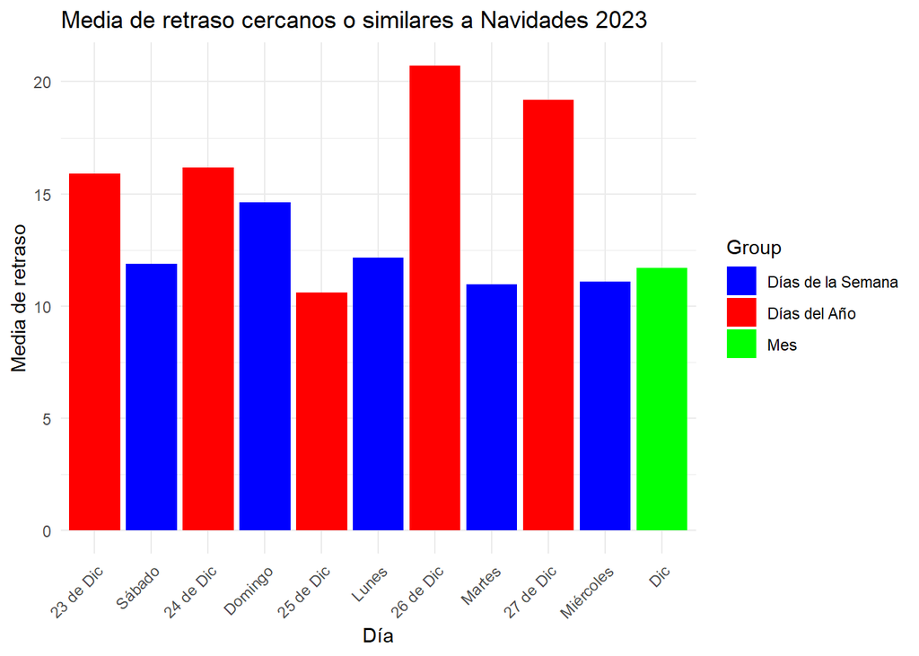

```r
media_retraso_25D <- media_retraso_25D %>%
  mutate(WEEKDAY_NAME = "25 de Dic")

media_retraso_26D <- media_retraso_26D %>%
  mutate(WEEKDAY_NAME = "26 de Dic")

media_retraso_27D <- media_retraso_27D %>%
  mutate(WEEKDAY_NAME = "27 de Dic")

media_retraso_24D <- media_retraso_24D %>%
  mutate(WEEKDAY_NAME = "24 de Dic")

media_retraso_23D <- media_retraso_23D %>%
  mutate(WEEKDAY_NAME = "23 de Dic")

combined_data <- bind_rows(media_retraso_lunesD, media_retraso_25D, media_retraso_diciembre, media_retraso_23D, media_retraso_24D, media_retraso_26D, media_retraso_27D, media_retraso_domingoD, media_retraso_sabadoD, media_retraso_martesD, media_retraso_miercolesD)

combined_data <- combined_data %>%
  mutate(WEEKDAY_NAME = factor(WEEKDAY_NAME, levels = c("23 de Dic", "Sábado", "24 de Dic", "Domingo", "25 de Dic", "Lunes", "26 de Dic", "Martes", "27 de Dic", "Miércoles", "Dic")),
         Group = case_when(
           WEEKDAY_NAME %in% c("23 de Dic", "24 de Dic", "25 de Dic", "26 de Dic", "27 de Dic") ~ "Días del Año",
           WEEKDAY_NAME == "Dic" ~ "Mes",
           TRUE ~ "Días de la Semana"
         ))

ggplot(combined_data, aes(x = WEEKDAY_NAME, y = media_retraso, fill = Group)) +
  geom_bar(stat = "identity") +
  scale_fill_manual(values = c("Días del Año" = "red", "Mes" = "green", "Días de la Semana" = "blue")) +
  labs(title = "Media de retraso cercanos o similares a Navidades 2023",
       x = "Día",
       y = "Media de retraso") +
  theme_minimal()+
  theme(axis.text.x = element_text(angle = 45, hjust = 1))
```

En 2023 el 25 de Dicimbre si que vemos, al igual que con el 1 de Enero, como los retrasos los días posteriores a un festivo aumentan, pero aquí también obsevamos nuevamente como los días previos siguen teniendo un leve aumento,por otro lado el porpio festivo tiene un retraso menor que la media de días de la semana que le corresponde.

### 4.3.2 2022

```r
vuelos_25D_2022 <- vuelos2022[vuelos2022$MONTH == 12 & vuelos2022$DAY_OF_MONTH == 25, ]
media_retraso_25D_2022 <- vuelos_25D_2022 %>%
  group_by(DAY_OF_MONTH) %>%
  summarise(media_retraso = mean(salida_retraso))
print(media_retraso_25D_2022)
```

```
## # A tibble: 1 × 2
##   DAY_OF_MONTH media_retraso
##          <int>         <dbl>
## 1           25          46.1
```

```r
vuelos_24D_2022 <- vuelos2022[vuelos2022$MONTH == 12 & vuelos2022$DAY_OF_MONTH == 24, ]
media_retraso_24D_2022 <- vuelos_24D_2022 %>%
  group_by(DAY_OF_MONTH) %>%
  summarise(media_retraso = mean(salida_retraso))
print(media_retraso_24D_2022)
```

```
## # A tibble: 1 × 2
##   DAY_OF_MONTH media_retraso
##          <int>         <dbl>
## 1           24          62.4
```

```r
vuelos_23D_2022 <- vuelos2022[vuelos2022$MONTH == 12 & vuelos2022$DAY_OF_MONTH == 23, ]
media_retraso_23D_2022 <- vuelos_23D_2022 %>%
  group_by(DAY_OF_MONTH) %>%
  summarise(media_retraso = mean(salida_retraso))
print(media_retraso_23D_2022)
```

```
## # A tibble: 1 × 2
##   DAY_OF_MONTH media_retraso
##          <int>         <dbl>
## 1           23          65.2
```

```r
vuelos_26D_2022 <- vuelos2022[vuelos2022$MONTH == 12 & vuelos2022$DAY_OF_MONTH == 26, ]
media_retraso_26D_2022 <- vuelos_26D_2022 %>%
  group_by(DAY_OF_MONTH) %>%
  summarise(media_retraso = mean(salida_retraso))
print(media_retraso_26D_2022)
```

```
## # A tibble: 1 × 2
##   DAY_OF_MONTH media_retraso
##          <int>         <dbl>
## 1           26          43.7
```

```r
vuelos_27D_2022 <- vuelos2022[vuelos2022$MONTH == 12 & vuelos2022$DAY_OF_MONTH == 27, ]
media_retraso_27D_2022 <- vuelos_27D_2022 %>%
  group_by(DAY_OF_MONTH) %>%
  summarise(media_retraso = mean(salida_retraso))
print(media_retraso_27D_2022)
```

```
## # A tibble: 1 × 2
##   DAY_OF_MONTH media_retraso
##          <int>         <dbl>
## 1           27          33.9
```

```r
print(dias[vuelos2022[vuelos2022$DAY_OF_MONTH == 25 & vuelos2022$MONTH == 12, ]$DAY_OF_WEEK[1]])
```

```
## [1] "Domingo"
```

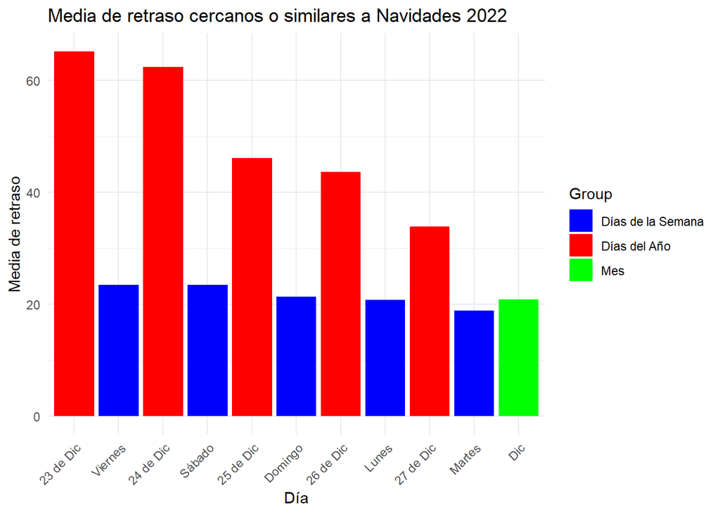

```r
media_retraso_25D_2022 <- media_retraso_25D_2022 %>%
  mutate(WEEKDAY_NAME = "25 de Dic")

media_retraso_26D_2022 <- media_retraso_26D_2022 %>%
  mutate(WEEKDAY_NAME = "26 de Dic")

media_retraso_27D_2022 <- media_retraso_27D_2022 %>%
  mutate(WEEKDAY_NAME = "27 de Dic")

media_retraso_24D_2022 <- media_retraso_24D_2022 %>%
  mutate(WEEKDAY_NAME = "24 de Dic")

media_retraso_23D_2022 <- media_retraso_23D_2022 %>%
  mutate(WEEKDAY_NAME = "23 de Dic")

combined_data <- bind_rows(media_retraso_lunesD22, media_retraso_25D_2022, media_retraso_diciembre_2022, media_retraso_23D_2022, media_retraso_24D_2022, media_retraso_26D_2022, media_retraso_27D_2022, media_retraso_domingoD22, media_retraso_sabadoD22, media_retraso_martesD22, media_retraso_viernesD22)

combined_data <- combined_data %>%
  mutate(WEEKDAY_NAME = factor(WEEKDAY_NAME, levels = c("23 de Dic", "Viernes", "24 de Dic", "Sábado", "25 de Dic", "Domingo", "26 de Dic", "Lunes", "27 de Dic", "Martes", "Dic")),
         Group = case_when(
           WEEKDAY_NAME %in% c("23 de Dic", "24 de Dic", "25 de Dic", "26 de Dic", "27 de Dic") ~ "Días del Año",
           WEEKDAY_NAME == "Dic" ~ "Mes",
           TRUE ~ "Días de la Semana"
         ))

ggplot(combined_data, aes(x = WEEKDAY_NAME, y = media_retraso, fill = Group)) +
  geom_bar(stat = "identity") +
  scale_fill_manual(values = c("Días del Año" = "red", "Mes" = "green", "Días de la Semana" = "blue")) +
  labs(title = "Media de retraso cercanos o similares a Navidades 2022",
       x = "Día",
       y = "Media de retraso") +
  theme_minimal()+
  theme(axis.text.x = element_text(angle = 45, hjust = 1))
```

### 4.3.3 2021

```r
vuelos_25D_2021 <- vuelos2021[vuelos2021$MONTH == 12 & vuelos2021$DAY_OF_MONTH == 25, ]
media_retraso_25D_2021 <- vuelos_25D_2021 %>%
  group_by(DAY_OF_MONTH) %>%
  summarise(media_retraso = mean(salida_retraso))
print(media_retraso_25D_2021)
```

```
## # A tibble: 1 × 2
##   DAY_OF_MONTH media_retraso
##          <int>         <dbl>
## 1           25          12.0
```

```r
vuelos_24D_2021 <- vuelos2021[vuelos2021$MONTH == 12 & vuelos2021$DAY_OF_MONTH == 24, ]
media_retraso_24D_2021 <- vuelos_24D_2021 %>%
  group_by(DAY_OF_MONTH) %>%
  summarise(media_retraso = mean(salida_retraso))
print(media_retraso_24D_2021)
```

```
## # A tibble: 1 × 2
##   DAY_OF_MONTH media_retraso
##          <int>         <dbl>
## 1           24          13.6
```

```r
vuelos_23D_2021 <- vuelos2021[vuelos2021$MONTH == 12 & vuelos2021$DAY_OF_MONTH == 23, ]
media_retraso_23D_2021 <- vuelos_23D_2021 %>%
  group_by(DAY_OF_MONTH) %>%
  summarise(media_retraso = mean(salida_retraso))
print(media_retraso_23D_2021)
```

```
## # A tibble: 1 × 2
##   DAY_OF_MONTH media_retraso
##          <int>         <dbl>
## 1           23          14.4
```

```r
vuelos_26D_2021 <- vuelos2021[vuelos2021$MONTH == 12 & vuelos2021$DAY_OF_MONTH == 26, ]
media_retraso_26D_2021 <- vuelos_26D_2021 %>%
  group_by(DAY_OF_MONTH) %>%
  summarise(media_retraso = mean(salida_retraso))
print(media_retraso_26D_2021)
```

```
## # A tibble: 1 × 2
##   DAY_OF_MONTH media_retraso
##          <int>         <dbl>
## 1           26          26.1
```

```r
vuelos_27D_2021 <- vuelos2021[vuelos2021$MONTH == 12 & vuelos2021$DAY_OF_MONTH == 27, ]
media_retraso_27D_2021 <- vuelos_27D_2021 %>%
  group_by(DAY_OF_MONTH) %>%
  summarise(media_retraso = mean(salida_retraso))
print(media_retraso_27D_2021)
```

```
## # A tibble: 1 × 2
##   DAY_OF_MONTH media_retraso
##          <int>         <dbl>
## 1           27          33.1
```

```r
print(dias[vuelos2021[vuelos2021$DAY_OF_MONTH == 25 & vuelos2021$MONTH == 12, ]$DAY_OF_WEEK[1]])
```

```
## [1] "Sabado"
```

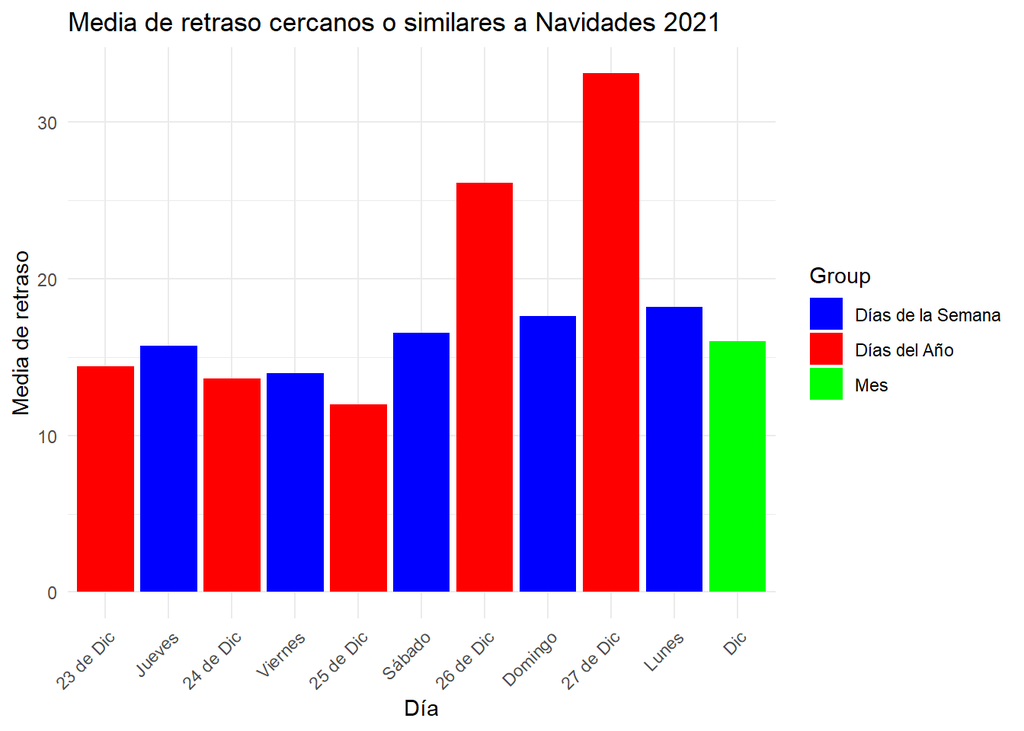

```r
media_retraso_25D_2021 <- media_retraso_25D_2021 %>%
  mutate(WEEKDAY_NAME = "25 de Dic")

media_retraso_26D_2021 <- media_retraso_26D_2021 %>%
  mutate(WEEKDAY_NAME = "26 de Dic")

media_retraso_27D_2021 <- media_retraso_27D_2021 %>%
  mutate(WEEKDAY_NAME = "27 de Dic")

media_retraso_24D_2021 <- media_retraso_24D_2021 %>%
  mutate(WEEKDAY_NAME = "24 de Dic")

media_retraso_23D_2021 <- media_retraso_23D_2021 %>%
  mutate(WEEKDAY_NAME = "23 de Dic")

media_retraso_diciembre_2021 <- media_retraso_por_mes2021 %>%
  filter(MONTH == "Dec") %>%
  mutate(WEEKDAY_NAME = "Dic")

combined_data <- bind_rows(media_retraso_lunesD21, media_retraso_25D_2021, media_retraso_diciembre_2021, media_retraso_23D_2021, media_retraso_24D_2021, media_retraso_26D_2021, media_retraso_27D_2021, media_retraso_domingoD21, media_retraso_sabadoD21, media_retraso_juevesD21, media_retraso_viernesD21)

combined_data <- combined_data %>%
  mutate(WEEKDAY_NAME = factor(WEEKDAY_NAME, levels = c("23 de Dic", "Jueves", "24 de Dic", "Viernes", "25 de Dic", "Sábado", "26 de Dic", "Domingo", "27 de Dic", "Lunes", "Dic")),
         Group = case_when(
           WEEKDAY_NAME %in% c("23 de Dic", "24 de Dic", "25 de Dic", "26 de Dic", "27 de Dic") ~ "Días del Año",
           WEEKDAY_NAME == "Dic" ~ "Mes",
           TRUE ~ "Días de la Semana"
         ))

ggplot(combined_data, aes(x = WEEKDAY_NAME, y = media_retraso, fill = Group)) +
  geom_bar(stat = "identity") +
  scale_fill_manual(values = c("Días del Año" = "red", "Mes" = "green", "Días de la Semana" = "blue")) +
  labs(title = "Media de retraso cercanos o similares a Navidades 2021",
       x = "Día",
       y = "Media de retraso") +
  theme_minimal()+
  theme(axis.text.x = element_text(angle = 45, hjust = 1))
```

Mirando en 2021 encontramos lo que habiamos visto en todos los gráficos anteriores, exceptuando el del 25 de Diciembre de 2022, que cada vez parece ser una irregularidad.

## 4.4 El Día de la Independencia

### 4.4.1 2023

Vamos a mirar ahora otro festivo, el 4 de julio

```r
vuelos_4J <- vuelos[vuelos$MONTH == 7 & vuelos$DAY_OF_MONTH == 4, ]
media_retraso_4J <- vuelos_4J %>%
  group_by(DAY_OF_MONTH) %>%
  summarise(media_retraso = mean(salida_retraso))
print(media_retraso_4J)
```

```
## # A tibble: 1 × 2
##   DAY_OF_MONTH media_retraso
##          <int>         <dbl>
## 1            4          13.3
```

```r
vuelos_2J <- vuelos[vuelos$MONTH == 7 & vuelos$DAY_OF_MONTH == 2, ]
media_retraso_2J <- vuelos_2J %>%
  group_by(DAY_OF_MONTH) %>%
  summarise(media_retraso = mean(salida_retraso))
print(media_retraso_2J)
```

```
## # A tibble: 1 × 2
##   DAY_OF_MONTH media_retraso
##          <int>         <dbl>
## 1            2          24.3
```

```r
vuelos_3J <- vuelos[vuelos$MONTH == 7 & vuelos$DAY_OF_MONTH == 3, ]
media_retraso_3J <- vuelos_3J %>%
  group_by(DAY_OF_MONTH) %>%
  summarise(media_retraso = mean(salida_retraso))
print(media_retraso_3J)
```

```
## # A tibble: 1 × 2
##   DAY_OF_MONTH media_retraso
##          <int>         <dbl>
## 1            3          13.1
```

```r
vuelos_5J <- vuelos[vuelos$MONTH == 7 & vuelos$DAY_OF_MONTH == 5, ]
media_retraso_5J <- vuelos_5J %>%
  group_by(DAY_OF_MONTH) %>%
  summarise(media_retraso = mean(salida_retraso))
print(media_retraso_5J)
```

```
## # A tibble: 1 × 2
##   DAY_OF_MONTH media_retraso
##          <int>         <dbl>
## 1            5          23.8
```

```r
vuelos_6J <- vuelos[vuelos$MONTH == 7 & vuelos$DAY_OF_MONTH == 6, ]
media_retraso_6J <- vuelos_6J %>%
  group_by(DAY_OF_MONTH) %>%
  summarise(media_retraso = mean(salida_retraso))
print(media_retraso_6J)
```

```
## # A tibble: 1 × 2
##   DAY_OF_MONTH media_retraso
##          <int>         <dbl>
## 1            6          21.3
```

```r
print(dias[vuelos[vuelos$DAY_OF_MONTH == 4 & vuelos$MONTH == 7, ]$DAY_OF_WEEK[1]])
```

```
## [1] "Martes"
```

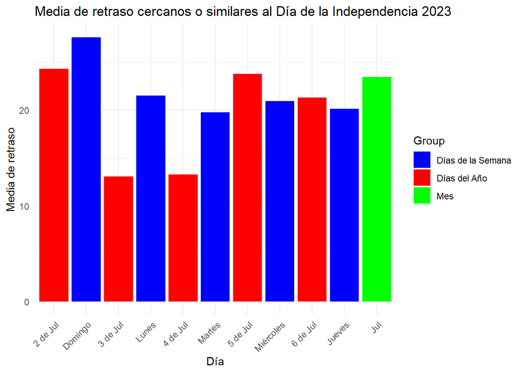

```r
media_retraso_2J <- media_retraso_2J %>%
  mutate(WEEKDAY_NAME = "2 de Jul")

media_retraso_3J <- media_retraso_3J %>%
  mutate(WEEKDAY_NAME = "3 de Jul")

media_retraso_4J <- media_retraso_4J %>%
  mutate(WEEKDAY_NAME = "4 de Jul")

media_retraso_5J <- media_retraso_5J %>%
  mutate(WEEKDAY_NAME = "5 de Jul")

media_retraso_6J <- media_retraso_6J %>%
  mutate(WEEKDAY_NAME = "6 de Jul")

media_retraso_julio <- media_retraso_por_mes2023 %>%
  filter(MONTH == "Jul") %>%
  mutate(WEEKDAY_NAME = "Jul")

combined_data <- bind_rows(media_retraso_2J, media_retraso_3J, media_retraso_4J, media_retraso_5J, media_retraso_6J, media_retraso_julio, media_retraso_martesJ, media_retraso_domingoJ, media_retraso_lunesJ, media_retraso_juevesJ, media_retraso_miercolesJ)

combined_data <- combined_data %>%
  mutate(WEEKDAY_NAME = factor(WEEKDAY_NAME, levels = c("2 de Jul", "Domingo", "3 de Jul", "Lunes", "4 de Jul", "Martes", "5 de Jul", "Miércoles", "6 de Jul", "Jueves", "Jul")),
         Group = case_when(
           WEEKDAY_NAME %in% c("2 de Jul", "3 de Jul", "4 de Jul", "5 de Jul", "6 de Jul") ~ "Días del Año",
           WEEKDAY_NAME == "Jul" ~ "Mes",
           TRUE ~ "Días de la Semana"
         ))

ggplot(combined_data, aes(x = WEEKDAY_NAME, y = media_retraso, fill = Group)) +
  geom_bar(stat = "identity") +
  scale_fill_manual(values = c("Días del Año" = "red", "Mes" = "green", "Días de la Semana" = "blue")) +
  labs(title = "Media de retraso cercanos o similares al Día de la Independencia 2023",
       x = "Día",
       y = "Media de retraso") +
  theme_minimal()+
  theme(axis.text.x = element_text(angle = 45, hjust = 1))
```

### 4.4.2 2022

```r
vuelos_4J_2022 <- vuelos2022[vuelos2022$MONTH == 7 & vuelos2022$DAY_OF_MONTH == 4, ]
media_retraso_4J_2022 <- vuelos_4J_2022 %>%
  group_by(DAY_OF_MONTH) %>%
  summarise(media_retraso = mean(salida_retraso))
print(media_retraso_4J_2022)
```

```
## # A tibble: 1 × 2
##   DAY_OF_MONTH media_retraso
##          <int>         <dbl>
## 1            4          9.06
```

```r
vuelos_2J_2022 <- vuelos2022[vuelos2022$MONTH == 7 & vuelos2022$DAY_OF_MONTH == 2, ]
media_retraso_2J_2022 <- vuelos_2J_2022 %>%
  group_by(DAY_OF_MONTH) %>%
  summarise(media_retraso = mean(salida_retraso))
print(media_retraso_2J_2022)
```

```
## # A tibble: 1 × 2
##   DAY_OF_MONTH media_retraso
##          <int>         <dbl>
## 1            2          16.3
```

```r
vuelos_3J_2022 <- vuelos2022[vuelos2022$MONTH == 7 & vuelos2022$DAY_OF_MONTH == 3, ]
media_retraso_3J_2022 <- vuelos_3J_2022 %>%
  group_by(DAY_OF_MONTH) %>%
  summarise(media_retraso = mean(salida_retraso))
print(media_retraso_3J_2022)
```

```
## # A tibble: 1 × 2
##   DAY_OF_MONTH media_retraso
##          <int>         <dbl>
## 1            3          10.9
```

```r
vuelos_5J_2022 <- vuelos2022[vuelos2022$MONTH == 7 & vuelos2022$DAY_OF_MONTH == 5, ]
media_retraso_5J_2022 <- vuelos_5J_2022 %>%
  group_by(DAY_OF_MONTH) %>%
  summarise(media_retraso = mean(salida_retraso))
print(media_retraso_5J_2022)
```

```
## # A tibble: 1 × 2
##   DAY_OF_MONTH media_retraso
##          <int>         <dbl>
## 1            5          13.8
```

```r
vuelos_6J_2022 <- vuelos2022[vuelos2022$MONTH == 7 & vuelos2022$DAY_OF_MONTH == 6, ]
media_retraso_6J_2022 <- vuelos_6J_2022 %>%
  group_by(DAY_OF_MONTH) %>%
  summarise(media_retraso = mean(salida_retraso))
print(media_retraso_6J_2022)
```

```
## # A tibble: 1 × 2
##   DAY_OF_MONTH media_retraso
##          <int>         <dbl>
## 1            6          14.1
```

```r
print(dias[vuelos2022[vuelos2022$DAY_OF_MONTH == 4 & vuelos2022$MONTH == 7, ]$DAY_OF_WEEK[1]])
```

```
## [1] "Lunes"
```

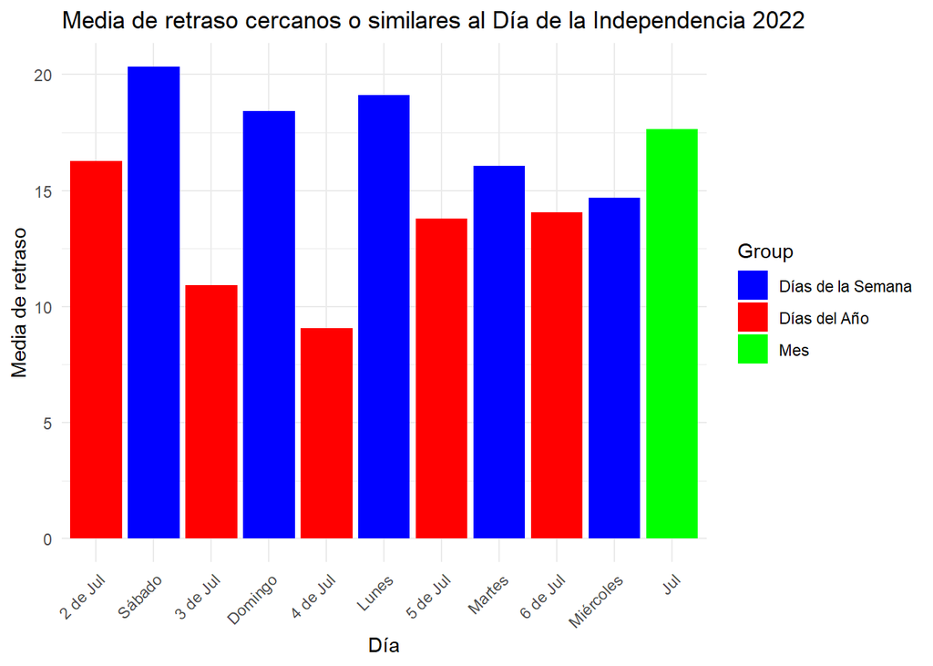

```r
media_retraso_2J_2022 <- media_retraso_2J_2022 %>%
  mutate(WEEKDAY_NAME = "2 de Jul")

media_retraso_3J_2022 <- media_retraso_3J_2022 %>%
  mutate(WEEKDAY_NAME = "3 de Jul")

media_retraso_4J_2022 <- media_retraso_4J_2022 %>%
  mutate(WEEKDAY_NAME = "4 de Jul")

media_retraso_5J_2022 <- media_retraso_5J_2022 %>%
  mutate(WEEKDAY_NAME = "5 de Jul")

media_retraso_6J_2022 <- media_retraso_6J_2022 %>%
  mutate(WEEKDAY_NAME = "6 de Jul")

media_retraso_julio22 <- media_retraso_por_mes2022 %>%
  filter(MONTH == "Jul") %>%
  mutate(WEEKDAY_NAME = "Jul")

combined_data <- bind_rows(media_retraso_2J_2022, media_retraso_3J_2022, media_retraso_4J_2022, media_retraso_5J_2022, media_retraso_6J_2022, media_retraso_julio22, media_retraso_martesJ22, media_retraso_domingoJ22, media_retraso_lunesJ22, media_retraso_sabadoJ22, media_retraso_miercolesJ22)

combined_data <- combined_data %>%
  mutate(WEEKDAY_NAME = factor(WEEKDAY_NAME, levels = c("2 de Jul", "Sábado", "3 de Jul", "Domingo", "4 de Jul", "Lunes", "5 de Jul", "Martes", "6 de Jul", "Miércoles", "Jul")),
         Group = case_when(
           WEEKDAY_NAME %in% c("2 de Jul", "3 de Jul", "4 de Jul", "5 de Jul", "6 de Jul") ~ "Días del Año",
           WEEKDAY_NAME == "Jul" ~ "Mes",
           TRUE ~ "Días de la Semana"
         ))

ggplot(combined_data, aes(x = WEEKDAY_NAME, y = media_retraso, fill = Group)) +
  geom_bar(stat = "identity") +
  scale_fill_manual(values = c("Días del Año" = "red", "Mes" = "green", "Días de la Semana" = "blue")) +
  labs(title = "Media de retraso cercanos o similares al Día de la Independencia 2022",
       x = "Día",
       y = "Media de retraso") +
  theme_minimal()+
  theme(axis.text.x = element_text(angle = 45, hjust = 1))
```

### 4.4.3 2021

```r
vuelos_4J_2021 <- vuelos2021[vuelos2021$MONTH == 7 & vuelos2021$DAY_OF_MONTH == 4, ]
media_retraso_4J_2021 <- vuelos_4J_2021 %>%
  group_by(DAY_OF_MONTH) %>%
  summarise(media_retraso = mean(salida_retraso))
print(media_retraso_4J_2021)
```

```
## # A tibble: 1 × 2
##   DAY_OF_MONTH media_retraso
##          <int>         <dbl>
## 1            4          11.9
```

```r
vuelos_2J_2021 <- vuelos2021[vuelos2021$MONTH == 7 & vuelos2021$DAY_OF_MONTH == 2, ]
media_retraso_2J_2021 <- vuelos_2J_2021 %>%
  group_by(DAY_OF_MONTH) %>%
  summarise(media_retraso = mean(salida_retraso))
print(media_retraso_2J_2021)
```

```
## # A tibble: 1 × 2
##   DAY_OF_MONTH media_retraso
##          <int>         <dbl>
## 1            2          29.8
```

```r
vuelos_3J_2021 <- vuelos2021[vuelos2021$MONTH == 7 & vuelos2021$DAY_OF_MONTH == 3, ]
media_retraso_3J_2021 <- vuelos_3J_2021 %>%
  group_by(DAY_OF_MONTH) %>%
  summarise(media_retraso = mean(salida_retraso))
print(media_retraso_3J_2021)
```

```
## # A tibble: 1 × 2
##   DAY_OF_MONTH media_retraso
##          <int>         <dbl>
## 1            3          22.7
```

```r
vuelos_5J_2021 <- vuelos2021[vuelos2021$MONTH == 7 & vuelos2021$DAY_OF_MONTH == 5, ]
media_retraso_5J_2021 <- vuelos_5J_2021 %>%
  group_by(DAY_OF_MONTH) %>%
  summarise(media_retraso = mean(salida_retraso))
print(media_retraso_5J_2021)
```

```
## # A tibble: 1 × 2
##   DAY_OF_MONTH media_retraso
##          <int>         <dbl>
## 1            5          14.7
```

```r
vuelos_6J_2021 <- vuelos2021[vuelos2021$MONTH == 7 & vuelos2021$DAY_OF_MONTH == 6, ]
media_retraso_6J_2021 <- vuelos_6J_2021 %>%
  group_by(DAY_OF_MONTH) %>%
  summarise(media_retraso = mean(salida_retraso))
print(media_retraso_6J_2021)
```

```
## # A tibble: 1 × 2
##   DAY_OF_MONTH media_retraso
##          <int>         <dbl>
## 1            6          13.8
```

```r
print(dias[vuelos2021[vuelos2021$DAY_OF_MONTH == 4 & vuelos2021$MONTH == 7, ]$DAY_OF_WEEK[1]])
```

```
## [1] "Domingo"
```

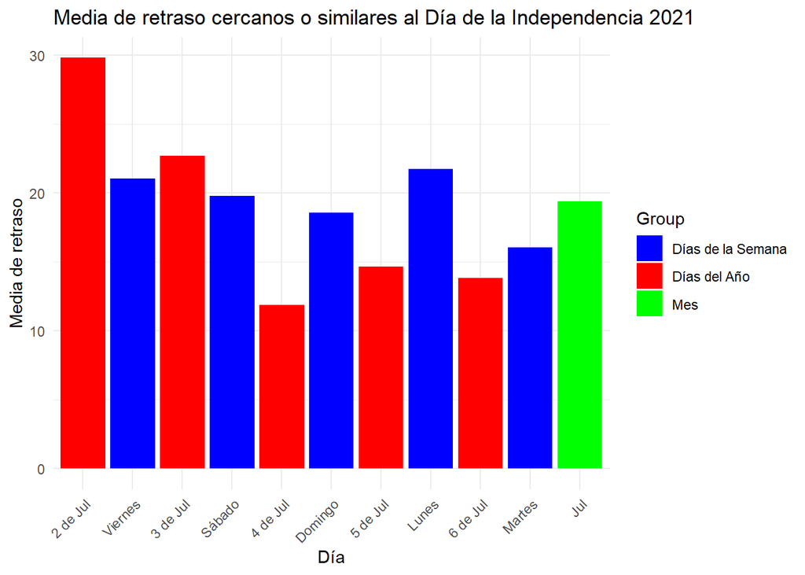

```r
media_retraso_2J_2021 <- media_retraso_2J_2021 %>%
  mutate(WEEKDAY_NAME = "2 de Jul")

media_retraso_3J_2021 <- media_retraso_3J_2021 %>%
  mutate(WEEKDAY_NAME = "3 de Jul")

media_retraso_4J_2021 <- media_retraso_4J_2021 %>%
  mutate(WEEKDAY_NAME = "4 de Jul")

media_retraso_5J_2021 <- media_retraso_5J_2021 %>%
  mutate(WEEKDAY_NAME = "5 de Jul")

media_retraso_6J_2021 <- media_retraso_6J_2021 %>%
  mutate(WEEKDAY_NAME = "6 de Jul")

media_retraso_julio21 <- media_retraso_por_mes2021 %>%
  filter(MONTH == "Jul") %>%
  mutate(WEEKDAY_NAME = "Jul")

combined_data <- bind_rows(media_retraso_2J_2021, media_retraso_3J_2021, media_retraso_4J_2021, media_retraso_5J_2021, media_retraso_6J_2021, media_retraso_julio21, media_retraso_martesJ21, media_retraso_domingoJ21, media_retraso_lunesJ21, media_retraso_sabadoJ21, media_retraso_viernesJ21)

combined_data <- combined_data %>%
  mutate(WEEKDAY_NAME = factor(WEEKDAY_NAME, levels = c("2 de Jul", "Viernes", "3 de Jul", "Sábado", "4 de Jul", "Domingo", "5 de Jul", "Lunes", "6 de Jul", "Martes", "Jul")),
         Group = case_when(
           WEEKDAY_NAME %in% c("2 de Jul", "3 de Jul", "4 de Jul", "5 de Jul", "6 de Jul") ~ "Días del Año",
           WEEKDAY_NAME == "Jul" ~ "Mes",
           TRUE ~ "Días de la Semana"
         ))

ggplot(combined_data, aes(x = WEEKDAY_NAME, y = media_retraso, fill = Group)) +
  geom_bar(stat = "identity", position = "dodge") +
  scale_fill_manual(values = c("Días del Año" = "red", "Mes" = "green", "Días de la Semana" = "blue")) +
  labs(title = "Media de retraso cercanos o similares al Día de la Independencia 2021",
       x = "Día",
       y = "Media de retraso") +
  theme_minimal() +
  theme(axis.text.x = element_text(angle = 45, hjust = 1))
```

## 4.5 El Día de Acción de Gracias

### 4.5.1 2023

Por ello vamos a mirarlo con una ultima festividad, el Día de Acción de Gracias.

```r
vuelos_23N <- vuelos[vuelos$MONTH == 11 & vuelos$DAY_OF_MONTH == 23, ]
media_retraso_23N <- vuelos_23N %>%
  group_by(DAY_OF_MONTH) %>%
  summarise(media_retraso = mean(salida_retraso))
print(media_retraso_23N)
```

```
## # A tibble: 1 × 2
##   DAY_OF_MONTH media_retraso
##          <int>         <dbl>
## 1           23          4.00
```

```r
vuelos_22N <- vuelos[vuelos$MONTH == 11 & vuelos$DAY_OF_MONTH == 22, ]
media_retraso_22N <- vuelos_22N %>%
  group_by(DAY_OF_MONTH) %>%
  summarise(media_retraso = mean(salida_retraso))
print(media_retraso_22N)
```

```
## # A tibble: 1 × 2
##   DAY_OF_MONTH media_retraso
##          <int>         <dbl>
## 1           22          8.84
```

```r
vuelos_21N <- vuelos[vuelos$MONTH == 11 & vuelos$DAY_OF_MONTH == 21, ]
media_retraso_21N <- vuelos_21N %>%
  group_by(DAY_OF_MONTH) %>%
  summarise(media_retraso = mean(salida_retraso))
print(media_retraso_21N)
```

```
## # A tibble: 1 × 2
##   DAY_OF_MONTH media_retraso
##          <int>         <dbl>
## 1           21          12.8
```

```r
vuelos_24N <- vuelos[vuelos$MONTH == 11 & vuelos$DAY_OF_MONTH == 24, ]
media_retraso_24N <- vuelos_24N %>%
  group_by(DAY_OF_MONTH) %>%
  summarise(media_retraso = mean(salida_retraso))
print(media_retraso_24N)
```

```
## # A tibble: 1 × 2
##   DAY_OF_MONTH media_retraso
##          <int>         <dbl>
## 1           24          7.70
```

```r
vuelos_25N <- vuelos[vuelos$MONTH == 11 & vuelos$DAY_OF_MONTH == 25, ]
media_retraso_25N <- vuelos_25N %>%
  group_by(DAY_OF_MONTH) %>%
  summarise(media_retraso = mean(salida_retraso))
print(media_retraso_25N)
```

```
## # A tibble: 1 × 2
##   DAY_OF_MONTH media_retraso
##          <int>         <dbl>
## 1           25          11.3
```

```r
print(dias[vuelos[vuelos$DAY_OF_MONTH == 23 & vuelos$MONTH == 11, ]$DAY_OF_WEEK[1]])
```

```
## [1] "Jueves"
```

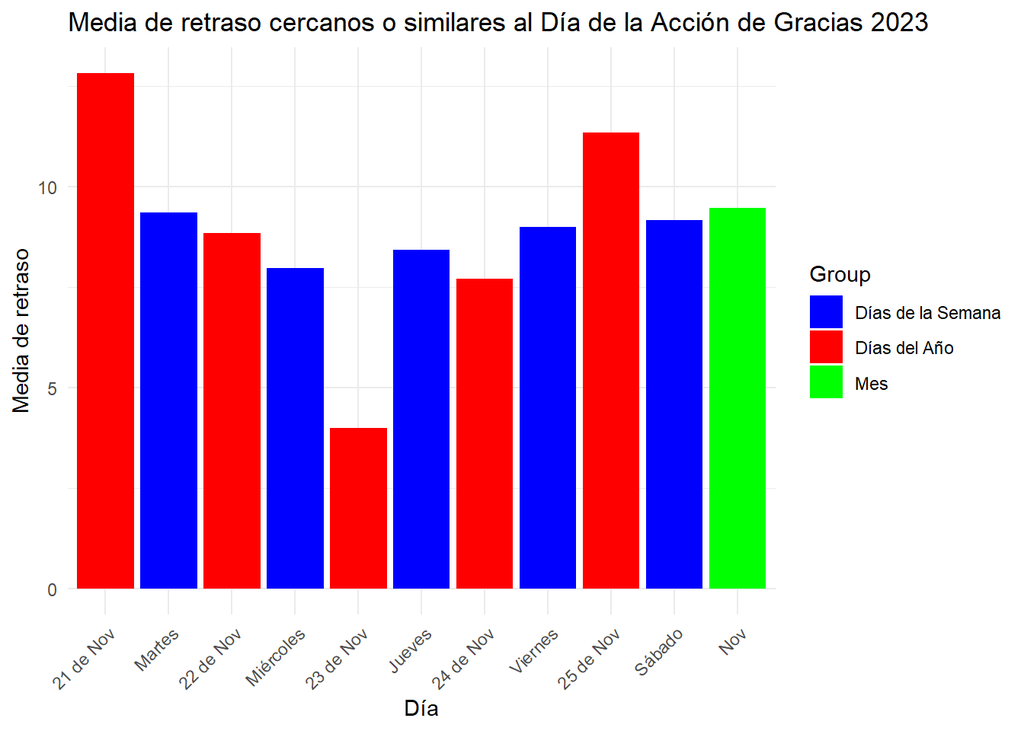

```r
media_retraso_21N <- media_retraso_21N %>%
  mutate(WEEKDAY_NAME = "21 de Nov")

media_retraso_22N <- media_retraso_22N %>%
  mutate(WEEKDAY_NAME = "22 de Nov")

media_retraso_23N <- media_retraso_23N %>%
  mutate(WEEKDAY_NAME = "23 de Nov")

media_retraso_24N <- media_retraso_24N %>%
  mutate(WEEKDAY_NAME = "24 de Nov")

media_retraso_25N <- media_retraso_25N %>%
  mutate(WEEKDAY_NAME = "25 de Nov")

media_retraso_noviembre <- media_retraso_por_mes2023 %>%
  filter(MONTH == "Nov") %>%
  mutate(WEEKDAY_NAME = "Nov")

combined_data <- bind_rows(media_retraso_21N, media_retraso_22N, media_retraso_23N, media_retraso_24N, media_retraso_25N, media_retraso_noviembre, media_retraso_martesN, media_retraso_sabadoN, media_retraso_viernesN, media_retraso_juevesN, media_retraso_miercolesN)

combined_data <- combined_data %>%
  mutate(WEEKDAY_NAME = factor(WEEKDAY_NAME, levels = c("21 de Nov", "Martes", "22 de Nov", "Miércoles", "23 de Nov", "Jueves", "24 de Nov", "Viernes", "25 de Nov", "Sábado", "Nov")),
         Group = case_when(
           WEEKDAY_NAME %in% c("21 de Nov", "22 de Nov", "23 de Nov", "24 de Nov", "25 de Nov") ~ "Días del Año",
           WEEKDAY_NAME == "Nov" ~ "Mes",
           TRUE ~ "Días de la Semana"
         ))

ggplot(combined_data, aes(x = WEEKDAY_NAME, y = media_retraso, fill = Group)) +
  geom_bar(stat = "identity") +
  scale_fill_manual(values = c("Días del Año" = "red", "Mes" = "green", "Días de la Semana" = "blue")) +
  labs(title = "Media de retraso cercanos o similares al Día de la Acción de Gracias 2023",
       x = "Día",
       y = "Media de retraso") +
  theme_minimal()+
  theme(axis.text.x = element_text(angle = 45, hjust = 1))
```

### 4.5.2 2022

```r
vuelos_23N_2022 <- vuelos2022[vuelos2022$MONTH == 11 & vuelos2022$DAY_OF_MONTH == 23, ]
media_retraso_23N_2022 <- vuelos_23N_2022 %>%
  group_by(DAY_OF_MONTH) %>%
  summarise(media_retraso = mean(salida_retraso))
print(media_retraso_23N_2022)
```

```
## # A tibble: 1 × 2
##   DAY_OF_MONTH media_retraso
##          <int>         <dbl>
## 1           23          10.0
```

```r
vuelos_22N_2022 <- vuelos2022[vuelos2022$MONTH == 11 & vuelos2022$DAY_OF_MONTH == 22, ]
media_retraso_22N_2022 <- vuelos_22N_2022 %>%
  group_by(DAY_OF_MONTH) %>%
  summarise(media_retraso = mean(salida_retraso))
print(media_retraso_22N_2022)
```

```
## # A tibble: 1 × 2
##   DAY_OF_MONTH media_retraso
##          <int>         <dbl>
## 1           22          10.5
```

```r
vuelos_26N_2022 <- vuelos2022[vuelos2022$MONTH == 11 & vuelos2022$DAY_OF_MONTH == 26, ]
media_retraso_26N_2022 <- vuelos_26N_2022 %>%
  group_by(DAY_OF_MONTH) %>%
  summarise(media_retraso = mean(salida_retraso))
print(media_retraso_26N_2022)
```

```
## # A tibble: 1 × 2
##   DAY_OF_MONTH media_retraso
##          <int>         <dbl>
## 1           26          12.4
```

```r
vuelos_24N_2022 <- vuelos2022[vuelos2022$MONTH == 11 & vuelos2022$DAY_OF_MONTH == 24, ]
media_retraso_24N_2022 <- vuelos_24N_2022 %>%
  group_by(DAY_OF_MONTH) %>%
  summarise(media_retraso = mean(salida_retraso))
print(media_retraso_24N_2022)
```

```
## # A tibble: 1 × 2
##   DAY_OF_MONTH media_retraso
##          <int>         <dbl>
## 1           24          10.5
```

```r
vuelos_25N_2022 <- vuelos2022[vuelos2022$MONTH == 11 & vuelos2022$DAY_OF_MONTH == 25, ]
media_retraso_25N_2022 <- vuelos_25N_2022 %>%
  group_by(DAY_OF_MONTH) %>%
  summarise(media_retraso = mean(salida_retraso))
print(media_retraso_25N_2022)
```

```
## # A tibble: 1 × 2
##   DAY_OF_MONTH media_retraso
##          <int>         <dbl>
## 1           25          8.34
```

```r
print(dias[vuelos2022[vuelos2022$DAY_OF_MONTH == 24 & vuelos2022$MONTH == 11, ]$DAY_OF_WEEK[1]])
```

```
## [1] "Jueves"
```

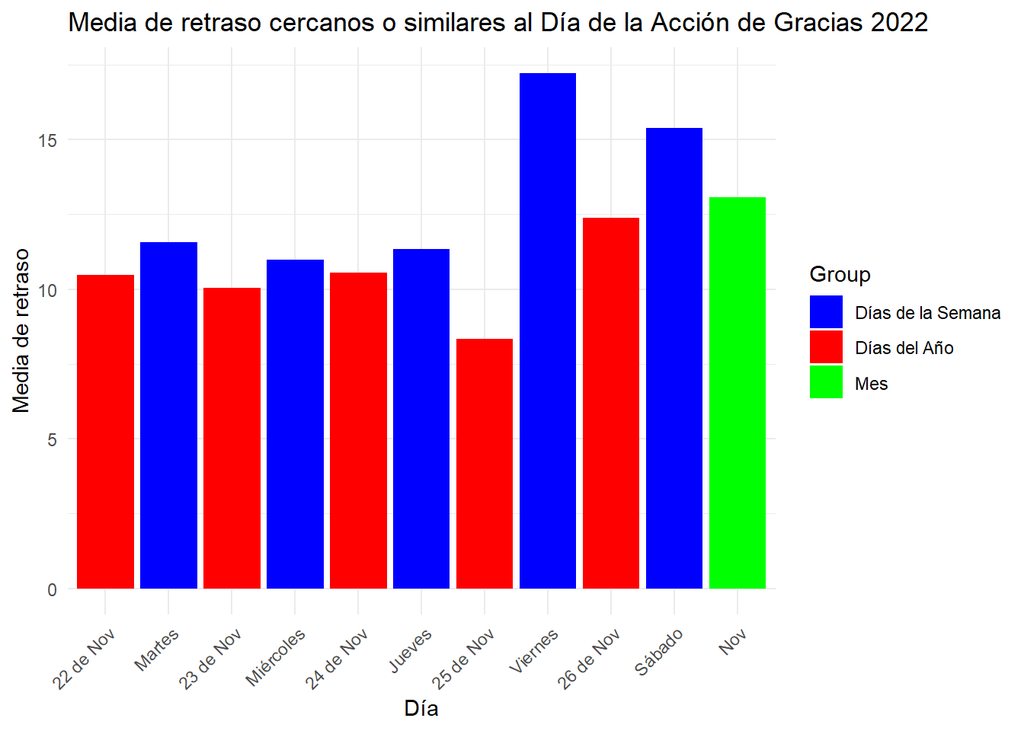

```r
media_retraso_26N_2022 <- media_retraso_26N_2022 %>%
  mutate(WEEKDAY_NAME = "26 de Nov")

media_retraso_22N_2022 <- media_retraso_22N_2022 %>%
  mutate(WEEKDAY_NAME = "22 de Nov")

media_retraso_23N_2022 <- media_retraso_23N_2022 %>%
  mutate(WEEKDAY_NAME = "23 de Nov")

media_retraso_24N_2022 <- media_retraso_24N_2022 %>%
  mutate(WEEKDAY_NAME = "24 de Nov")

media_retraso_25N_2022 <- media_retraso_25N_2022 %>%
  mutate(WEEKDAY_NAME = "25 de Nov")

media_retraso_noviembre22 <- media_retraso_por_mes2022 %>%
  filter(MONTH == "Nov") %>%
  mutate(WEEKDAY_NAME = "Nov")

combined_data <- bind_rows(media_retraso_26N_2022, media_retraso_22N_2022, media_retraso_23N_2022, media_retraso_24N_2022, media_retraso_25N_2022, media_retraso_noviembre22, media_retraso_martesN22, media_retraso_sabadoN22, media_retraso_viernesN22, media_retraso_juevesN22, media_retraso_miercolesN22)

combined_data <- combined_data %>%
  mutate(WEEKDAY_NAME = factor(WEEKDAY_NAME, levels = c("22 de Nov", "Martes", "23 de Nov", "Miércoles", "24 de Nov", "Jueves", "25 de Nov", "Viernes", "26 de Nov", "Sábado", "Nov")),
         Group = case_when(
           WEEKDAY_NAME %in% c("22 de Nov", "23 de Nov", "24 de Nov", "25 de Nov", "26 de Nov") ~ "Días del Año",
           WEEKDAY_NAME == "Nov" ~ "Mes",
           TRUE ~ "Días de la Semana"
         ))

ggplot(combined_data, aes(x = WEEKDAY_NAME, y = media_retraso, fill = Group)) +
  geom_bar(stat = "identity") +
  scale_fill_manual(values = c("Días del Año" = "red", "Mes" = "green", "Días de la Semana" = "blue")) +
  labs(title = "Media de retraso cercanos o similares al Día de la Acción de Gracias 2022",
       x = "Día",
       y = "Media de retraso") +
  theme_minimal()+
  theme(axis.text.x = element_text(angle = 45, hjust = 1))
```

### 4.5.3 2021

```r
vuelos_23N_2021 <- vuelos2021[vuelos2021$MONTH == 11 & vuelos2021$DAY_OF_MONTH == 23, ]
media_retraso_23N_2021 <- vuelos_23N_2021 %>%
  group_by(DAY_OF_MONTH) %>%
  summarise(media_retraso = mean(salida_retraso))
print(media_retraso_23N_2021)
```

```
## # A tibble: 1 × 2
##   DAY_OF_MONTH media_retraso
##          <int>         <dbl>
## 1           23          10.0
```

```r
vuelos_27N_2021 <- vuelos2021[vuelos2021$MONTH == 11 & vuelos2021$DAY_OF_MONTH == 27, ]
media_retraso_27N_2021 <- vuelos_27N_2021 %>%
  group_by(DAY_OF_MONTH) %>%
  summarise(media_retraso = mean(salida_retraso))
print(media_retraso_27N_2021)
```

```
## # A tibble: 1 × 2
##   DAY_OF_MONTH media_retraso
##          <int>         <dbl>
## 1           27          9.97
```

```r
vuelos_26N_2021 <- vuelos2021[vuelos2021$MONTH == 11 & vuelos2021$DAY_OF_MONTH == 26, ]
media_retraso_26N_2021 <- vuelos_26N_2021 %>%
  group_by(DAY_OF_MONTH) %>%
  summarise(media_retraso = mean(salida_retraso))
print(media_retraso_26N_2021)
```

```
## # A tibble: 1 × 2
##   DAY_OF_MONTH media_retraso
##          <int>         <dbl>
## 1           26          6.87
```

```r
vuelos_24N_2021 <- vuelos2021[vuelos2021$MONTH == 11 & vuelos2021$DAY_OF_MONTH == 24, ]
media_retraso_24N_2021 <- vuelos_24N_2021 %>%
  group_by(DAY_OF_MONTH) %>%
  summarise(media_retraso = mean(salida_retraso))
print(media_retraso_24N_2021)
```

```
## # A tibble: 1 × 2
##   DAY_OF_MONTH media_retraso
##          <int>         <dbl>
## 1           24          8.62
```

```r
vuelos_25N_2021 <- vuelos2021[vuelos2021$MONTH == 11 & vuelos2021$DAY_OF_MONTH == 25, ]
media_retraso_25N_2021 <- vuelos_25N_2021 %>%
  group_by(DAY_OF_MONTH) %>%
  summarise(media_retraso = mean(salida_retraso))
print(media_retraso_25N_2021)
```

```
## # A tibble: 1 × 2
##   DAY_OF_MONTH media_retraso
##          <int>         <dbl>
## 1           25          7.58
```

```r
print(dias[vuelos2021[vuelos2021$DAY_OF_MONTH == 25 & vuelos2021$MONTH == 11, ]$DAY_OF_WEEK[1]])
```

```
## [1] "Jueves"
```

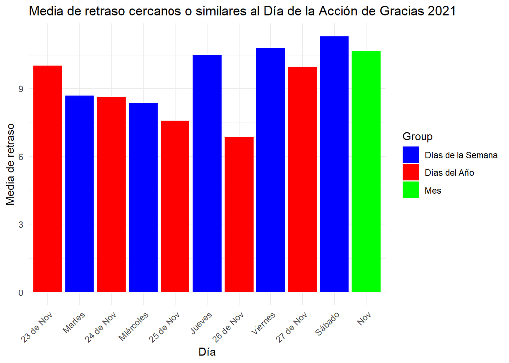

```r
media_retraso_26N_2021 <- media_retraso_26N_2021 %>%
  mutate(WEEKDAY_NAME = "26 de Nov")

media_retraso_27N_2021 <- media_retraso_27N_2021 %>%
  mutate(WEEKDAY_NAME = "27 de Nov")

media_retraso_23N_2021 <- media_retraso_23N_2021 %>%
  mutate(WEEKDAY_NAME = "23 de Nov")

media_retraso_24N_2021 <- media_retraso_24N_2021 %>%
  mutate(WEEKDAY_NAME = "24 de Nov")

media_retraso_25N_2021 <- media_retraso_25N_2021 %>%
  mutate(WEEKDAY_NAME = "25 de Nov")

media_retraso_noviembre21 <- media_retraso_por_mes2021 %>%
  filter(MONTH == "Nov") %>%
  mutate(WEEKDAY_NAME = "Nov")

combined_data <- bind_rows(media_retraso_26N_2021, media_retraso_27N_2021, media_retraso_23N_2021, media_retraso_24N_2021, media_retraso_25N_2021, media_retraso_noviembre21, media_retraso_martesN21, media_retraso_sabadoN21, media_retraso_viernesN21, media_retraso_juevesN21, media_retraso_miercolesN21)

combined_data <- combined_data %>%
  mutate(WEEKDAY_NAME = factor(WEEKDAY_NAME, levels = c("23 de Nov", "Martes", "24 de Nov", "Miércoles", "25 de Nov", "Jueves", "26 de Nov", "Viernes", "27 de Nov", "Sábado", "Nov")),
         Group = case_when(
           WEEKDAY_NAME %in% c("23 de Nov", "24 de Nov", "25 de Nov", "26 de Nov", "27 de Nov") ~ "Días del Año",
           WEEKDAY_NAME == "Nov" ~ "Mes",
           TRUE ~ "Días de la Semana"
         ))

ggplot(combined_data, aes(x = WEEKDAY_NAME, y = media_retraso, fill = Group)) +
  geom_bar(stat = "identity") +
  scale_fill_manual(values = c("Días del Año" = "red", "Mes" = "green", "Días de la Semana" = "blue")) +
  labs(title = "Media de retraso cercanos o similares al Día de la Acción de Gracias 2021",
       x = "Día",
       y = "Media de retraso") +
  theme_minimal()+
  theme(axis.text.x = element_text(angle = 45, hjust = 1))
```

# 5 Conclusiones de los retrasos los días festivos

Concluimos diciendo que no hay claro ningún patrón en el mismo festivo en diferentes años, pero sí que podemos ver algunas similitudes entre los distintos festivos del mismo años. En 2023 hay un aumento del retraso los días posteriores, pese a que en algunos este es muy pequeño y el día del festivo hay un descenso, menos en Año Nuevo que sorpresivamente aumenta. En 2022, en cambio, los festivos navideños tienen unas cifras de retraso mucho más elevadas los días cercanos y el propio festivo que las medias de los días y del mes, mientras que las otras dos festividades analizadas son justo lo contrario, todos los días de la franja que estamos escogiendo (5 días) tienen un retraso menor. Y en 2021 si que no vemos ningún tipo de relación ya que en unos festivos son los días previos y en otros los posteriores los que aumentan el retraso, únicamente se mantiene constante que el propio día de la festividad tiene un retraso medio un poco menor, comparado con el día de la semana y el mes.